# Using ARQ to investigate RDF data cube

mja@statgroup.dk

2016-06-29

# SPARQL scripts for the demographics cube (DC-DEMO-sample.ttl)

The examples below uses `arq` from Apache Jena (http://jena.apache.org). To install arq - download and unpack the latest version of apache-jena from (http://jena.apache.org/download/index.cgi). Then you need some way of invoking `arq`; I use a not-so-clever-approach: `cd ~/bin; ln -s /opt/apache-jena-2.13.0/bin/arq`.

Given a SPARQL query and RDF data, `arq` returns the result of the query. So this is the command line way of making a SPARQL query.

The use of arq is described in many places, see for example (http://www.learningsparql.com/).

The cd below in each code block is included because I could not find a quick way to get the code chunk executed in that directory. knitr is flexible enough to do it, I have not yet found the right way to do it. So, ignore the repeated cd ..

For making the SPARQL queries I used a simple trick - copy the turtle definition from the cube.ttl, and do a replace regexp in emacs using pattern `+\([^:]+\):\([^ ]+\) .*$` and replacement `\1:\2 ?\2 ;`.

## Get all member of qb:ComponentProperty

```bash
cd ../extdata/sample-rdf
arq --results ttl --data ../../../../rrdfqb/inst/extdata/cube-vocabulary-rdf/cube.ttl --query qb-construct-ComponentProperty.rq > fordot.ttl
rapper -i turtle -o dot fordot.ttl > fordot.dot
dot -x -Tpng -ograph.png fordot.dot
rm -f fordot.dot
```

```
## rapper: Parsing URI file:///home/ma/projects/rrdfqbcrnd0/rrdfqbcrndex/inst/extdata/sample-rdf/fordot.ttl with parser turtle
## rapper: Serializing with serializer dot
## rapper: Parsing returned 29 triples
```

ToDo(MJA): location for cube.ttl should be generated by the program - not using a directory reference

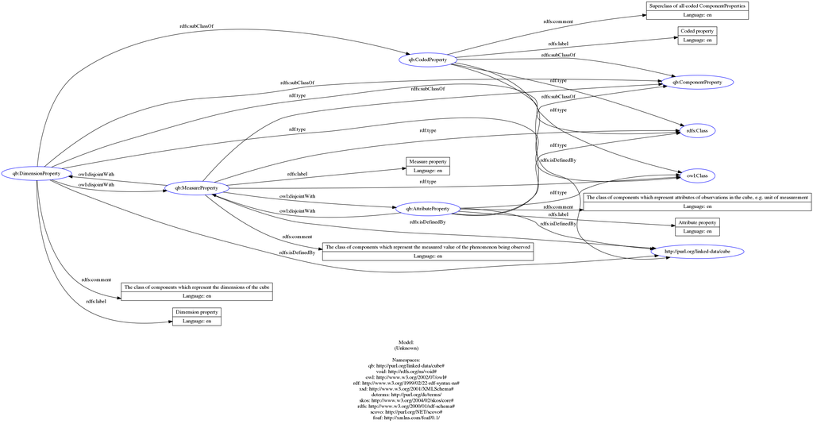

```r
knitr::include_graphics("../extdata/sample-rdf/graph.png")
```

The file is needed for rendering, so no clean up.

```bash
cd ../extdata/sample-rdf
rm -f graph.png
```

# How to run this .Rmd file